# Mapas

# Instalamos

```r
install.packages('rgeos', type='source')
install.packages('rgdal', type='source')
install.packages("mapproj")
```

Usamos la función readOGR para leer los archivos de estados.

```r
edo_shp <- readOGR("shapes" , "Estados")
class(edo_shp)
```

```
## [1] "SpatialPolygonsDataFrame"
## attr(,"package")
## [1] "sp"
```

Lo podemos graficar directamente con plot.

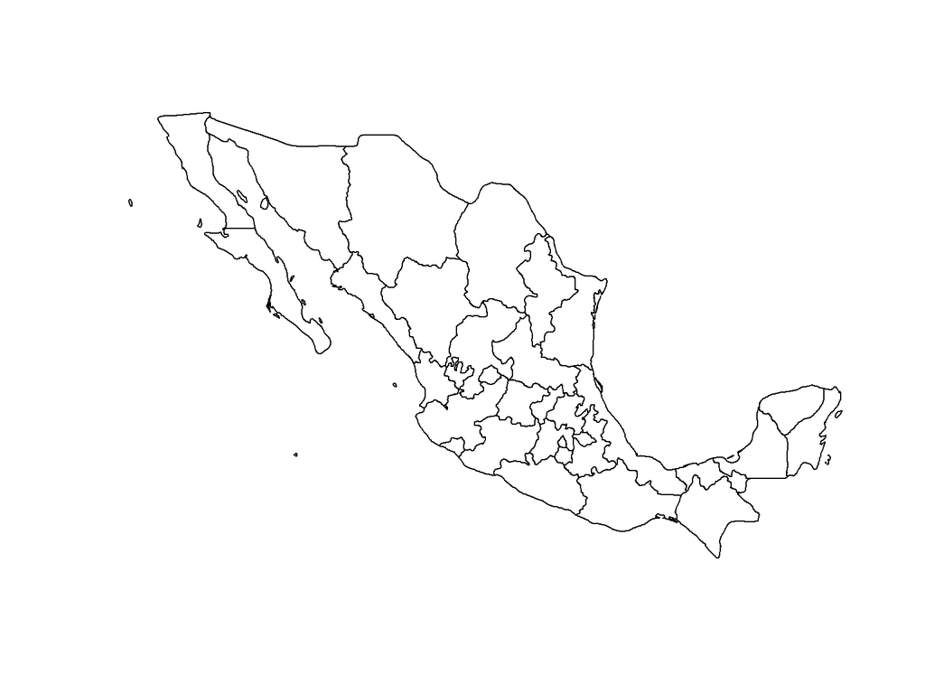

```r
plot(edo_shp)
```

Para poder graficarlo en ggplot debemos convertirlo en un dataframe.

Formamos el data frame (con fortify) que convierte los polígonos en puntos, les asigna el id (NOM_ENT) correspondiente, y asigna también un *grupo* que indica a que polígono corresponde cada punto.

```r
edo_df <- fortify(edo_shp, region = "NOM_ENT")
class(edo_df)
```

```
## [1] "data.frame"
```

```r
head(edo_df)
```

```
##        long      lat order  hole piece             id            group
## 1 -102.1068 22.29674     1 FALSE     1 Aguascalientes Aguascalientes.1
## 2 -102.1054 22.29639     2 FALSE     1 Aguascalientes Aguascalientes.1
## 3 -102.0971 22.29499     3 FALSE     1 Aguascalientes Aguascalientes.1
## 4 -102.0768 22.29267     4 FALSE     1 Aguascalientes Aguascalientes.1
## 5 -102.0649 22.28985     5 FALSE     1 Aguascalientes Aguascalientes.1
## 6 -102.0573 22.28697     6 FALSE     1 Aguascalientes Aguascalientes.1
```

Ya estamos listos para graficar, usaremos la geometría polígono.

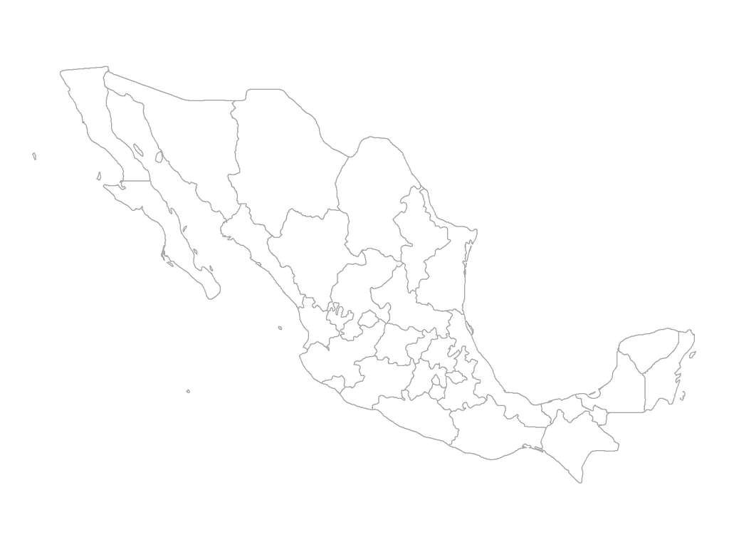

```r
ggplot(data = edo_df, aes(long, lat, group=group)) +
  geom_polygon(colour='darkgrey', fill='white') +
  coord_map(projection="mercator") +
  theme_nothing()
```

# Añadir variables al mapa

Nuestro objetivo final es hacer mapas para representar una variable, veamos como haríamos para representar el índice de carencias que creamos en la tarea.

```r
library(Hmisc)

conapo <- read.csv("data/indice_carencias.csv", stringsAsFactors=FALSE)

conapo$CVE <- read.table("data/conapo_2010.csv", header=TRUE, quote="\"",
  stringsAsFactors=FALSE, colClasses = "character")$CVE

# Creamos una variable categórica
conapo <- mutate(conapo, indice_cat = cut2(PC1, 5))
indice <- select(conapo, indice = PC1, indice_cat, CVE)

centro <- indice$CVE[conapo$NOM_ABR %in% c("DF", "Mex.", "Mor.")]

mun_shp <- readOGR("shapes" , "municipios_ligero")
names(mun_shp)
```

```
## [1] "OBJECTID" "CVE_ENT"  "CVE_MUN"  "NOM_MUN"  "id"
```

```r
mun_shp@data$CVE <- paste(as.character(mun_shp@data$CVE_ENT),
  as.character(mun_shp@data$CVE_MUN), sep = "")

mun_df <- fortify(mun_shp, region = "CVE")
```

Para incluirlas en el mapa añadimos las variables de interés a la base de datos mun_df. Para este ejemplo graficaremos únicamente una región. Podemos crear el subconjunto directamente del objeto *SpatialPolygonsDataFrame* pero en este ejemplo filtraremos la base de datos *data.frame*.

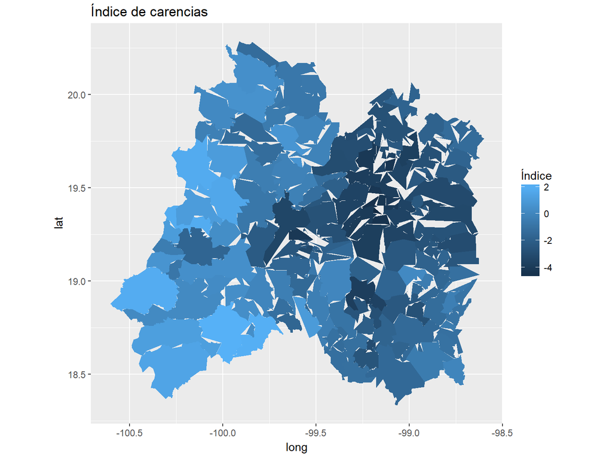

```r
indice <- indice %>% mutate(CVE = stringr::str_pad(CVE, 5, side = "left", pad = "0"))
mun_ind <- mun_df %>%
  mutate(CVE = id) %>%
  left_join(indice) %>%
  filter(CVE %in% centro)

ggplot() +
  geom_polygon(data = mun_ind, aes(long, lat, group = group, fill = indice)) +
  labs(title = "Índice de carencias", fill = "Índice") +
  coord_fixed()
```

En el siguiente mapa los colores son a nivel municipio pero dibujamos las fronteras a nivel estado para evitar que los bordes opaquen los datos.

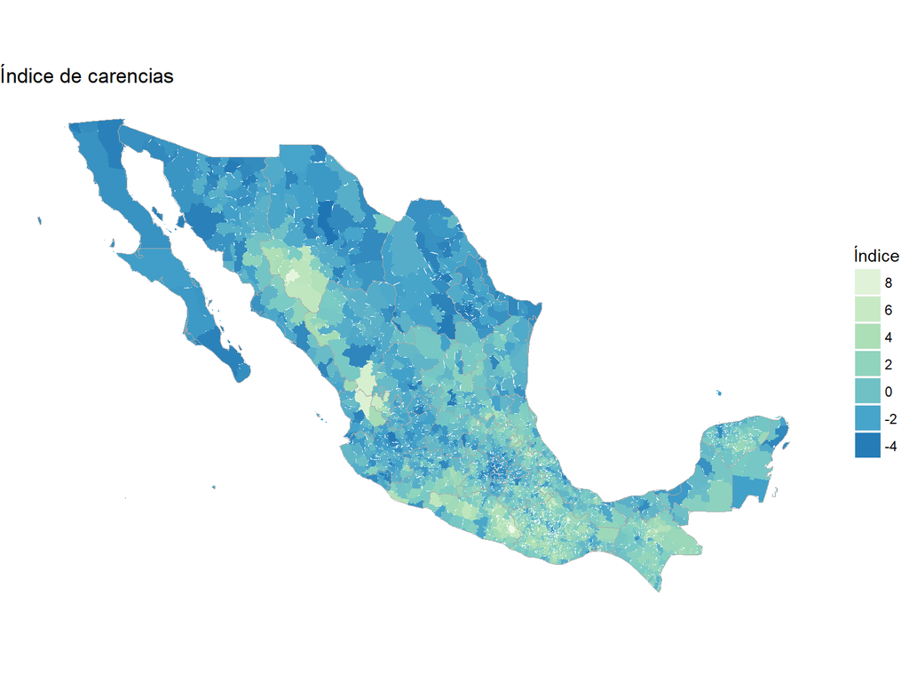

```r
mun_shp_2 <- spTransform(mun_shp, CRS("+proj=longlat +datum=WGS84"))

mun_df <- fortify(mun_shp_2, region = "CVE")
mun_ind <- mun_df %>%
  mutate(CVE = id) %>%
  left_join(indice)

ggplot() +
  geom_polygon(data = mun_ind, aes(long, lat, group = group, fill = indice)) +
  geom_polygon(data = edo_df, aes(x = long, y = lat, group = group),
    fill = NA, color = "darkgray", size = 0.25) +
  labs(title = "Índice de carencias", fill = "Índice") +
  theme_nothing(legend = TRUE) + #fondo blanco
  guides(fill = guide_legend(reverse = TRUE)) +
  scale_fill_distiller(palette = "GnBu", breaks = pretty_breaks(n = 10)) + #paleta
  coord_map()
```